# The Tidybiology Renal Malignancy Score

SH Tay

2022-09-30

## Browsing data

This is a scRNAseq dataset obtained from a sizeable cohort of Southeast Asian patients with early renal cell cancers - the team managed to sample tissues from various organs (wow I wonder how the ethics board approved that) and identified 10 cell clusters.

(Actually it’s just the scRNAseq dataset from the Tidyverse of Madness).

The dataset comprises of 10 cell clusters with 13 accompanying parameters.

```r
glimpse(scRNAseq)
```

```
## Rows: 54,703
## Columns: 23
## $ gene_name                <chr> "WASH7P", "MIR6859-1", "MIR1302-2HG", "MIR130…
## $ gene_description         <chr> "WASP family homolog 7, pseudogene", "microRN…
## $ chromosome_scaffold_name <chr> "1", "1", "1", "1", "1", "1", "1", "1", "1", …
## $ strand                   <int> -1, -1, 1, 1, -1, 1, 1, -1, -1, 1, -1, -1, -1…
## $ gene_start_bp            <int> 14404, 17369, 29554, 30366, 34554, 52473, 654…
## $ gene_end_bp              <int> 29570, 17436, 31097, 30503, 36081, 53312, 715…
## $ transcript_length        <dbl> 1350, 67, 711, 137, 1186, 839, 2617, 2747, 13…
## $ gene_percent_gc_content  <dbl> 54.43, 61.76, 48.84, 31.16, 50.26, 37.74, 32.…
## $ gene_type                <chr> "unprocessed_pseudogene", "miRNA", "lncRNA", …
## $ tidybiology_score        <dbl> -0.61675495, 0.62248697, -0.41465915, -0.4989…
## $ gene_stable_id           <chr> "ENSG00000227232", "ENSG00000278267", "ENSG00…
## $ transcript_stable_id     <chr> "ENST00000488147", "ENST00000619216", "ENST00…
## $ organ                    <chr> "other", "other", "other", "other", "other", …
## $ cell_1                   <int> 21, 15, 14, 24, 16, 21, 23, 17, 18, 16, 18, 2…
## $ cell_2                   <int> 19, 26, 20, 21, 24, 16, 28, 16, 9, 21, 24, 22…
## $ cell_3                   <int> 20, 7, 8, 22, 13, 20, 27, 28, 19, 13, 32, 28,…
## $ cell_4                   <int> 20, 22, 13, 23, 26, 20, 19, 22, 28, 10, 21, 1…
## $ cell_5                   <int> 17, 25, 19, 28, 18, 23, 29, 24, 21, 18, 16, 2…
## $ cell_6                   <int> 7, 20, 24, 18, 18, 23, 22, 17, 15, 19, 22, 13…
## $ cell_7                   <int> 23, 20, 19, 22, 14, 22, 22, 19, 18, 29, 16, 2…
## $ cell_8                   <int> 17, 16, 16, 13, 13, 22, 14, 24, 28, 25, 15, 1…
## $ cell_9                   <int> 23, 17, 18, 17, 21, 23, 29, 22, 26, 14, 16, 2…
## $ cell_10                  <int> 14, 16, 27, 19, 18, 20, 15, 23, 24, 18, 25, 2…
```

## TidyBiology score and kidney malignancies

It has been widely reported that a TidyBiology score of more than 2.0 strongly correlates with oncogenic potential. I wanted to identify novel proto-oncogenes in the kidney that may be implicated in early renal cell cancers, and which cell type(s) highly express those genes.

First, I looked at the distribution of scores of genes present in the kidney.

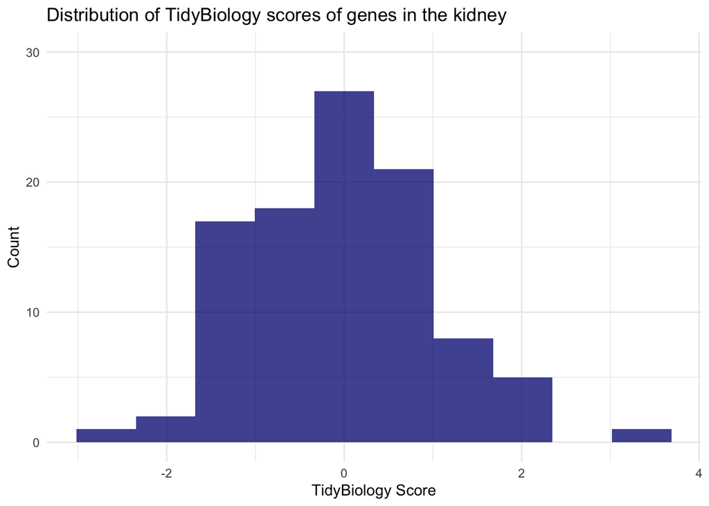

## Genes with high TidyBiology scores in the kidney - what are they?

After filtering for genes whose scores exceed 2.0, I looked into their identities and corresponding scores.

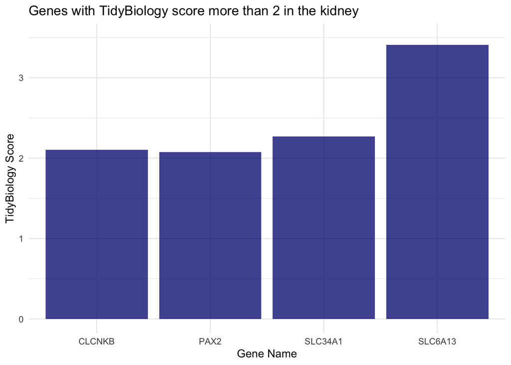

## Creating a TidyBiology Renal Malignancy Score

I first used a pivot table to reorganise the cell cluster columns so that I can obtain, per gene of interest, the number of reads for each cell cluster. I then summed up, per cell cluster, the reads for all genes to generate a score that measures malignancy potential.

```r
renal_score <- tidybiology_score_2 %>%
  pivot_longer(cols = cell_1:cell_10,  names_to = "Cluster", values_to = "value") %>%
  group_by(Cluster)%>%
  summarise(Malignancy_score=sum(value))
```

This is a summary of the malignancy scores in descending order.

```r
renal_score%>%
  arrange(desc(Malignancy_score))
```

```
## # A tibble: 10 × 2
##    Cluster Malignancy_score
##    <chr>              <int>
##  1 cell_6               400
##  2 cell_2               397
##  3 cell_7               390
##  4 cell_8               385
##  5 cell_3                89
##  6 cell_1                88
##  7 cell_4                83
##  8 cell_9                81
##  9 cell_10               80
## 10 cell_5                67
```

## Appreciating graphically the TidyBiology Renal Malignancy Scores of all 10 cell clusters

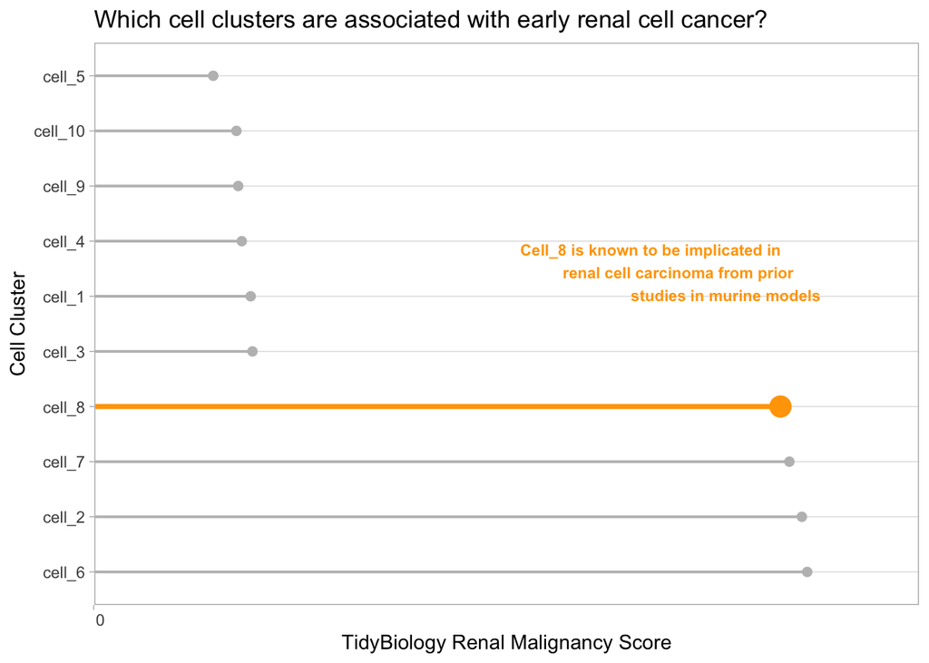

## Conclusions

4 cell clusters have high TidyBiology Renal Malignancy scores: cell_6, cell_2, cell_7 and cell_8. In particular, cell_8 is of great interest as its role in driving early renal cell carcinoma, a type of renal malignancy, has been reported in murine studies.

The 4 genes with high TidyBiology scores are also of interest, as they are essential to renal physiology but may be subverted in malignancy.

## Prioritized follow-up studies

I would study the 4 cell clusters with high TidyBiology Renal Malignancy scores - looking into their developmental trajectories and potential interactions with one another. I would then measure their levels in murine models of renal cancer with and without certain forms of treatment.

## Acknowledgements

I would like to acknowledge Professor Matthew Hirschey and the TidyBiology team for creating this wonderful course, Charles for the help rendered, and the geniuses who wrote up tidyverse and R.